# Duolingo Report Task

Reza Norouzian

03/10/2022

```r
library(htmltools)
library(tidyverse)
library(effects)
library(lme4)
library(broom.mixed)
library(emmeans)
library(knitr)
library(kableExtra)


# Helper functions to check or clean the model:

G_pca <- function(fit) {

  if(!inherits(fit, c("lmerMod","lmerModLmerTest","lme4","glmerMod"))) stop("Non-lme4 model detected.", call. = FALSE)
  obj <- summary(lme4::rePCA(fit))
  model <- lme4::VarCorr(fit)
  if(length(obj) == length(model)) {
    obj <- Map(function(x, z) {
      colnames(x$importance) <- paste(z, colnames(model[[z]]), sep = '_')
      x
    }, obj, names(obj))
  }
  else if(length(obj) == 1) {
    colnames(obj[[1]]$importance) <- unlist(mapply(paste, names(model), sapply(model, colnames), MoreArgs = list(sep = '_')))
  }
  return(obj)
}


#--------------------------------------------


clean_reg <- function(fm, nm) {
  vars <- vapply(attr(terms(fm), "variables"), deparse, "")[-1L]
  subpat <- paste0(gsub("([()])", "\\\\\\1", vars), collapse = "|")
  l <- rapply(strsplit(nm, ":"), sub, how = "list",
              perl = TRUE,
              pattern = sprintf("^(?!(%1$s)$)(%1$s)(.+)$", subpat),
              replacement = "\\3")
  vec <- vapply(l, paste0, "", collapse = ":")
  return(vec)
}

#--------------------------------------------


roundi <- function(x, digits = 7){

  if(!inherits(x, c("data.frame","tibble"))) stop("'x' must be a 'data.frame'.", call. = FALSE)

  num <- sapply(x, is.numeric)

  x[num] <- lapply(x[num], function(i) formatC(round(i, digits), digits, format = "f"))

  return(x)
}
```

# 1 A quick overview of internal validity issues

In light of the several measurable, confounding variables in the experiment, it would be difficult to reject or support the use of the new “written production” item type to the Duolingo quizzes.

Below, I elaborate on the underlying reasons for this decision. In a single-group experiment, quality of the findings crucially depend on the internal validity of the experiment. For instance, at the item level, while we know the distinction among the item types, no information regarding item characteristics (e.g., item difficulty, item discrimination) is available. As a result, it is difficult to assume that the pattern in the learning gains (shown below) would hold in light of varying item characteristics. Indeed, no identifying information regarding the items (e.g., item_id) is available in the data.

As another example, given the variation in the time intervals between the occurrence of the quizzes (pre and post) across the test takers, it is likely that some test takers have been able to use additional resources beyond Duolingo’s courses which they could be asked about at the time of the post-test. Once again, it is difficult to assume that the pattern in the learning gains (shown below) would hold in light of varying time intervals across test-takers. Indeed, no information regarding the test takers’ characteristics (e.g., age, L1) is available in the data.

Figure 1 proposes a range of variables that may be invoked when such an experiment is to be conducted. This may be useful as an approximate starting point for future experiments of this kind. While the goal is not to control for each and every potential confounding variable (e.g., unobserved confounders like test takers’ medical or family-related history), certain measurable confounders either directly or by proxy (e.g., using time interval between tests as a crude indication of motivational level or purpose of learning) can be accounted for to ensure a higher degree of internal validity.

[figure not shown]

# 2 Current learning gains despite the internal validity issues

Given the current data, a multilevel logistic model from two candidate models (see the reproducible code below) was fit to predict the probability of correct response for the test takers across the four item types before and after using the Duolingo’s instructional unit. Figure 2 provides this prediction for our four types of items. As can be seen, a gap is visible between the test takers’ performance on the newly added production-type items and that on the multiple-choice items at the pre-testing occasion.

```r
# Data import

dat <- read_csv("https://docs.google.com/uc?id=1cMFFJCan0e_3oE_eegcpgpku_s7bOFMG&export=download") %>%
pivot_longer(pre_score:post_score, names_to = "time", values_to = "y") %>%
  mutate(time = recode_factor(time, "pre_score"="Baseline", "post_score"="Post-test"))



form1 <- y ~ item_type*time + (item_type | user_id)

form2 <- y ~ item_type*time + (1 | user_id)


m1 <- glmer(form1, family = binomial, data = dat,
            control =
              glmerControl(optimizer = "bobyqa",
                           optCtrl=list(maxfun=1e4)))


m2 <- glmer(form2, family = binomial, data = dat,
            control =
              glmerControl(optimizer = "bobyqa"))


# Model 1 is preferred
# anova(m1, m2)
```

```r
# Output on the odds ratio scale
out <- tidy(m1,exponentiate=TRUE)


reg_tab <- roundi(filter(out, effect == "fixed")[-(1:2)] %>% as.data.frame(),3) %>%
mutate(term = clean_reg(m1, names(fixef(m1))))


kbl(reg_tab, caption = "Multilevel Logistic Model (odds ratio scale)") %>%
 kable_classic(full_width = F)
```

Multilevel Logistic Model (odds ratio scale)

| term | estimate | std.error | statistic | p.value |
| --- | --- | --- | --- | --- |
| (Intercept) | 1.097 | 0.068 | 1.503 | 0.133 |
| multiple-choice_vocabulary | 22.600 | 19.044 | 3.700 | 0.000 |
| production_grammar | 0.628 | 0.061 | -4.819 | 0.000 |
| production_vocabulary | 3.521 | 0.456 | 9.715 | 0.000 |
| Post-test | 2.064 | 0.158 | 9.494 | 0.000 |
| multiple-choice_vocabulary:Post-test | 1.359 | 0.367 | 1.136 | 0.256 |
| production_grammar:Post-test | 1.522 | 0.199 | 3.213 | 0.001 |
| production_vocabulary:Post-test | 1.428 | 0.209 | 2.437 | 0.015 |

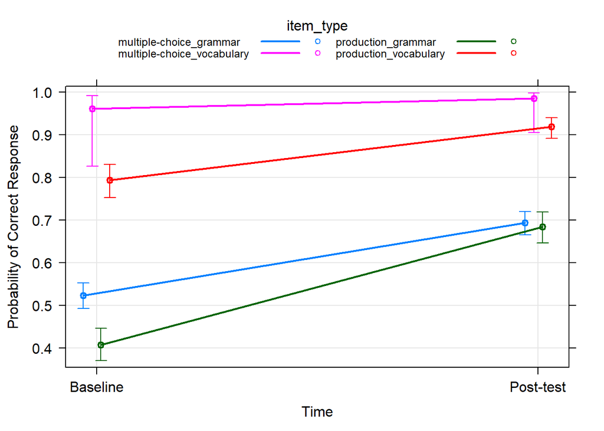

```r
rm_effect_sd <- roundi(filter(out, effect != "fixed")[-c(1:2,5:7)] %>% as.data.frame(),3)


# Predicted probabilities
plot(predictorEffects(m1)[2],
     multiline = TRUE,
     rug = FALSE,
     ci.style = "auto",
     type = "response",
     ylab = "Probability of Correct Response",
     main = NA,
     grid = TRUE,
     xlab = "Time")
```

```r
# Measure the gaps at the pre-test
ems <- emmeans(m1, pairwise ~ time*item_type,infer = c(FALSE, TRUE), type = "response")[[2]] %>%
  as.data.frame() %>% roundi(digits = 3)

pre_test_gap <- ems[c(4,17),]


kbl(pre_test_gap, caption = "Performance Gap at Pre-testing Occasion by Item Type") %>%
 kable_classic(full_width = F)
```

Performance Gap at Pre-testing Occasion by Item Type

|  | contrast | odds.ratio | SE | df | z.ratio | p.value |
| --- | --- | --- | --- | --- | --- | --- |
| 4 | (Baseline multiple-choice_grammar) / Baseline production_grammar | 1.592 | 0.154 | Inf | 4.819 | 0.000 |
| 17 | (Baseline multiple-choice_vocabulary) / Baseline production_vocabulary | 6.419 | 5.444 | Inf | 2.192 | 0.356 |

Given this wide pre-study gap, the learning gains for each language skill (grammar and vocabulary) were computed in two steps. First, the change in test-takers’ performance across the two testing occasions for each item type was obtained. Second, a planned statistical comparison between the two gains for each item type was conducted.

```r
# Two Planned contrasts

# 1- ((Baseline multiple-choice_grammar) - (Post-test multiple-choice_grammar)) - (Baseline production_grammar - (Post-test production_grammar))

# 2- ((Baseline multiple-choice_vocabulary) - (Post-test multiple-choice_vocabulary)) - (Baseline production_vocabulary - (Post-test production_vocabulary))

EMM <- emmeans(m1, ~ item_type * time, infer=c(FALSE,FALSE))

CON <- list(c1 = c(1, 0, -1, 0, -1, 0, 1, 0),
            c2 = c(0, 1, 0, -1, 0, -1, 0, 1))

pc <- roundi(as.data.frame(contrast(regrid(EMM), CON)),3)[-4]

pc$contrast <- c("((Baseline multiple-choice_grammar) - (Post-test multiple-choice_grammar)) - (Baseline production_grammar - (Post-test production_grammar))",

"((Baseline multiple-choice_vocabulary) - (Post-test multiple-choice_vocabulary)) - (Baseline production_vocabulary - (Post-test production_vocabulary)))")

kbl(pc, caption = "Planned Contrasts (Item Type Sensetivity to Learning Gains)") %>%
 kable_classic(full_width = F)
```

Planned Contrasts (Item Type Sensetivity to Learning Gains)

| contrast | estimate | SE | z.ratio | p.value |
| --- | --- | --- | --- | --- |
| ((Baseline multiple-choice_grammar) - (Post-test multiple-choice_grammar)) - (Baseline production_grammar - (Post-test production_grammar)) | 0.106 | 0.030 | 3.526 | 0.000 |
| ((Baseline multiple-choice_vocabulary) - (Post-test multiple-choice_vocabulary)) - (Baseline production_vocabulary - (Post-test production_vocabulary))) | 0.100 | 0.023 | 4.329 | 0.000 |

Both of these planned comparisons showed that the learning gains from the newly added production type items relative to those from their multiple-choice peers is significantly higher for the Duolingo users targeted in this single-group study.

# 3 Recommendations

As noted at the start of this brief report, the internal validity issues present in this experiment prevent me from recommending or discouraging the use of the newly added production type items. As with any large-scale, international testing context, users of Duolingo likely vary in systematic and random ways. In the present data, due to the limited number of systematic predictors of learning gains much of this variation was left unexplained and labeled as random variation by the statistical model.

The same sources of variation could also exist due to the different items given to the users. I suspect that for test security reasons, the size of the item pool is probably considerably larger than the number of test takers. This would mean that the reaction of test-takers might additionally depend on the specific batch of items they received. This factor could have a considerable impact on measuring the sensitivity of item types to the learning gains given the differential levels of user-item interactions.

Sincerely, Reza